Plotting alongside phylogeny Fernando Roa 23 08 2019

Go to home  
Go to monocentrics Vignette  
Go to holocentrics Vignette  
Go to groups Vignette  
Go to human Vignette

This guide shows the files to plot idiograms alongside a phylogeny

# 1 Load package

visit gitlab for installation instructions https://gitlab.com/ferroao/idiogramFISH

```r
#load package
library(idiogramFISH)
```

# 2 ggtree of iqtree and monocentrics

idiogramFISH comes with two trees, first we will plot a tree produced with iqtree (Nguyen *et al.*, 2015)

## Load the iqtree:

We will use phytools for that (Revell, 2019)

```r
require(ggplot2)
require(phytools)
require(ggpubr)
require(grid)   #pushViewport
require(ggtree)
# list.files(system.file('extdata', package = 'my_package') )

# find path of iqtree file
iqtreeFile    <- system.file("extdata", "eightSpIqtree.treefile", package = "idiogramFISH")

# load file as phylo object
iqtreephylo   <- read.newick(iqtreeFile) # phytools

# transform tree
iqtreephyloUM <- force.ultrametric(iqtreephylo, method= "extend") # phytools
```

## Make a ggtree (Yu and Lam, 2019)

```r
ggtreeOf8 <- ggtree(iqtreephyloUM) + geom_tiplab(size=6)
```

Modify optionally graphical parameters with ggplot and ggpubr: (Kassambara, 2019; Wickham *et al.*, 2019)

```r
gbuil2      <-  ggplot_build(ggtreeOf8)       # get ggplot_built
gtgbuild    <-  ggplot_gtable(gbuil2)         # get gtable from ggplot_built
gtgbuild$layout$clip[gtgbuild$layout$name == "panel"] <- "off"                # modify gtable
ggtreeOf8   <- as_ggplot(gtgbuild)            # back to ggplot
gtgbuildgg2 <- ggtreeOf8 +  theme(plot.margin = unit(c(1,9.5,3,1.5), "cm") ) # top right bottom left - modify margins
```

Our plot of the tree is ready, let’s get the order of species in tree

```r
iqtreephyloUM <- ladderize(iqtreephyloUM, right = FALSE)
is_tip <- iqtreephyloUM$edge[,2] <= length(iqtreephyloUM$tip.label)
ordered_tips  <- iqtreephyloUM$edge[is_tip, 2]
desiredOrder  <- rev(iqtreephyloUM$tip.label[ordered_tips])
```

## Order OTUs of data.frame of chr. data

Apply order of phylogeny to data.frame

```r
# make a vector without missing OTUs
desiredFiltered <- intersect(desiredOrder,allChrSizeSample$OTU)

# establish desired order
allChrSizeSample$OTU <- factor(allChrSizeSample$OTU, levels = desiredFiltered)

# order
allChrSizeSample     <- allChrSizeSample[order(allChrSizeSample$OTU),]
```

Now we have to establish where are the OTUs in the tree, that don’t have chr. data

```r
# Establish position of OTUs before missing data OTUs
matchres <- match(desiredOrder,desiredFiltered)
matchres[is.na(matchres)] <- "R"
reps     <- rle(matchres)
posOTUsBeforeMissing      <- as.numeric(matchres[which(matchres=="R")-1][which(matchres[which(matchres=="R")-1]!="R")] )

# This are the OTUs that come before missing chr. data OTUs
BeforeMissing             <- desiredFiltered[posOTUsBeforeMissing]

# This is the amount of missing OTUs, spaces to add (ghost karyotypes)
valuesOfMissRepsBefore    <- reps$lengths[which(reps$values=="R")]
```

## Plotting

Now we are ready to plot adding those arguments for `addMissingOTUAfter` and `missOTUspacings`

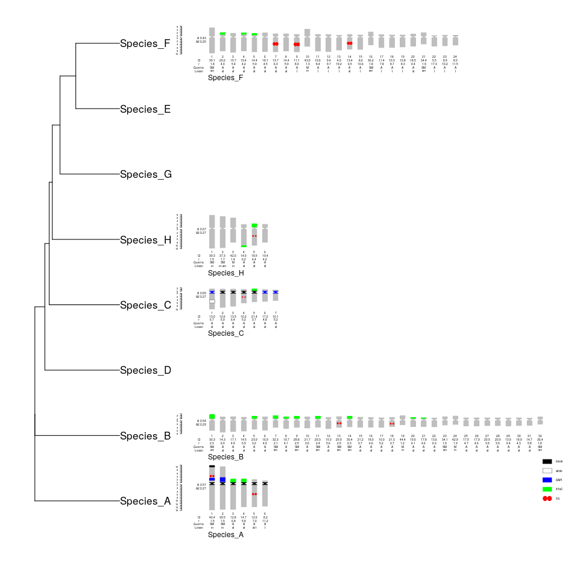

```r
# plot to png file
png(file="firstplot.png" ,width=962,height=962 )

par(omi=rep(0,4) , mar=c(0,1,2,1),
    mfrow=c(1,2) )   # one row two columns
par(fig=c(0,.3,0,1)) # location of left ghost plot
plot.new()           # ghost plot to the left
par(fig=c(.3,1,0,1)) # location of right plot

plotIdiograms(allChrSizeSample,                # data.frame of Chr. Sizes
              allMarksSample,                  # d.f. of Marks (not cen.)
              dfCenMarks = allCenMarksSample,  # d.f. of centromeric marks
              dfMarkColor =  mydfMaColor,      # d.f. of mark characteristics

              roundness = 10.5,                # roundness of vertices
              dotRoundCorr = .8,               # correct roundness aspect ratio
              lwd.chr=.5,                      # width of lines
              orderBySize = FALSE,             # don't order chr. by size
              centromereSize = 1.3,            # apparent cen. size
              OTUTextSize = 1,                 # Size of OTU name
              chrWidth =3,                     # width of chr.
              chrSpacing = 3,                  # horizontal spacing of chr.
              karSpacing = 1.8,                # karyotype vertical relative size with spacing

              nameChrIndexPos=4,               # move the name of chr. indexes to left
              morpho=TRUE,                     # add chr. morphology
              chrIndex = TRUE,                 # add chr. indices
              karIndex = TRUE,                 # add karyotype indices

              markLabelSpacer = 0              # spaces from rightmost chr. to legend
              ,legend="aside"                  # position of legends

              ,ylimTopMod = -.3                # modify ylim top margin
              ,ylimBotMod=.9                   # modify ylim bottom margin
              ,xlimRightMod=1                  # modify right xlim

              ,rulerPos = -1.6                 # position of rulers
              ,rulerNumberSize = .35           # font size of ruler number
              ,rulerNumberPos = .4             # position of ruler numbers

              ,addMissingOTUAfter = BeforeMissing          # OTUs after which there are ghost karyotypes - empty spaces
              ,missOTUspacings    = valuesOfMissRepsBefore # number of ghost karyotypes
)

# plot to the left the ggtree
pushViewport(viewport(layout = grid.layout(1, 2)))
pushViewport(viewport(layout.pos.col = 1, layout.pos.row = 1))
print(gtgbuildgg2,newpage=F)

# close png
dev.off()
```

# 3 plot of revBayes tree and holocentrics

Now we are going to plot a tree from revBayes (Höhna *et al.*, 2017)

## First, load the revBayes tree:

```r
require(ggplot2)
require(phytools)
require(ggpubr)
require(grid)   #pushViewport
require(ggtree)
require(treeio)

# find path of iqtree file
revBayesFile    <- system.file("extdata", "revBayesTutorial.tree", package = "idiogramFISH")

# load file as phylo object
revBayesPhylo   <- read.beast(revBayesFile) # ggtree or treeio

# transform tree
revBayesPhyloUM <- force.ultrametric(revBayesPhylo@phylo, method= "extend") # phytools
```

Then, get order of OTUs in tree

```r
is_tip           <- revBayesPhyloUM$edge[,2] <= length(revBayesPhyloUM$tip.label)
ordered_tips     <- revBayesPhyloUM$edge[is_tip, 2]
desiredorderRevB <- rev(revBayesPhyloUM$tip.label[ordered_tips])
```

## Order OTUs of data.frame of chr. data

First, create some data for holocentrics

```r
allChrSizeSampleHolo <- allChrSizeSample
allChrSizeSampleHolo <- allChrSizeSampleHolo[,c("OTU","chrName","longArmSize")]
colnames(allChrSizeSampleHolo)[which(names(allChrSizeSampleHolo)=="longArmSize")]<-"chrSize"

allMarksSampleHolo   <-allMarksSample
allMarksSampleHolo   <-allMarksSampleHolo[c("OTU","chrName","markName","markDistCen","markSize")]
colnames(allMarksSampleHolo)[which(names(allMarksSampleHolo)=="markDistCen")] <- "markPos"
allMarksSampleHolo[which(allMarksSampleHolo$markName=="5S"),]$markSize <- .5
```

Apply order of phylogeny to data.frame

```r
# make a vector without missing OTUs
desiredFiltered <- intersect(desiredorderRevB,allChrSizeSampleHolo$OTU)

# establish desired order
allChrSizeSampleHolo$OTU <- factor(allChrSizeSampleHolo$OTU, levels = desiredFiltered)

# order
allChrSizeSampleHolo <- allChrSizeSampleHolo[order(allChrSizeSampleHolo$OTU),]
```

Now we have to establish where are the OTUs in the tree, that don’t have chr. data

```r
# Establish position of OTUs before missing data OTUs
matchres <- match(desiredorderRevB,desiredFiltered)
matchres[is.na(matchres)]   <- "R"
reps     <- rle(matchres)
posOTUsBeforeMissing        <- as.numeric(matchres[which(matchres=="R")-1][which(matchres[which(matchres=="R")-1]!="R")] )

# This are the OTUs that come before missing chr. data OTUs
BeforeMissingPlot2          <- desiredFiltered[posOTUsBeforeMissing]

# This is the amount of missing OTUs, spaces to add (ghost karyotypes)
valuesOfMissRepsBeforePlot2 <- reps$lengths[which(reps$values=="R")]
```

## Plotting

Now we are ready to plot adding those arguments for `addMissingOTUAfter` and `missOTUspacings`

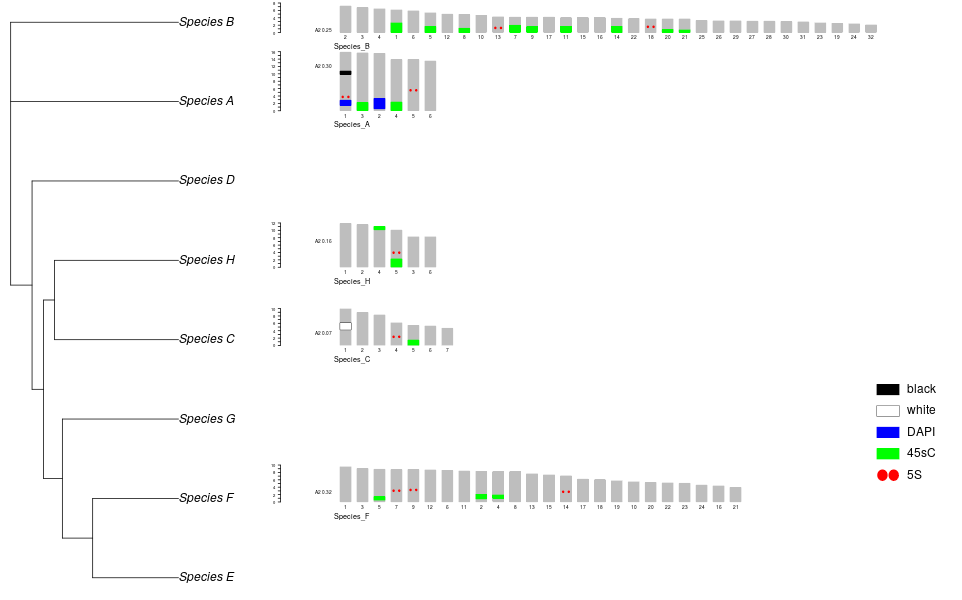

```r
# plot to png file
png(file=paste0("secondplot.png" ),width=962,height=600)

{
par(omi=rep(0,4) , mar=c(0,0,0,0), mfrow=c(1,2))
par(fig=c(0,.3,0,1))
plot(revBayesPhyloUM)
par(fig=c(0.3,1,0,1), new=TRUE)
par(mar=c(3,0,0,0))
plotIdiogramsHolo(allChrSizeSampleHolo,           # chr. size data.frame
              allMarksSampleHolo,                 # data.frame of marks' positions
              dfMarkColor =  mydfMaColor,         # d.f. of mark characteristics

              roundness = 10.5,                   # vertices roundness
              dotRoundCorr = 1.2,                 # correction of roundness of dots and vertices

              chrWidth =3,                        # width of chr.
              chrSpacing = 1.5,                   # horizontal spacing among chr.
              karIndex = TRUE                     # add karyotype index

              ,addMissingOTUAfter = BeforeMissingPlot2           # add ghost OTUs after these names
              ,missOTUspacings    = valuesOfMissRepsBeforePlot2  # how many ghosts, respectively
              ,lwd.chr=.5                         # line width

              ,legend="aside"                     # make legend to the right
              ,markLabelSpacer = 0                # dist. of legend to rightmost chr.
              ,markLabelSize = 1                  # font size of legend
              ,legendWidth = 2                    # width of square or dots of legend

              ,ylimTopMod = -.3                   # modify ylim of top
              ,ylimBotMod=-.9                     # modify ylim of bottom
              ,xlimRightMod=2                     # modify xlim of right

              ,rulerPos = -1.6                    # position of ruler
              ,rulerNumberSize = .35              # font size of number of ruler
              ,rulerNumberPos = .4                # position of ruler number

)
}

# close png
dev.off()
```

Höhna S, Landis MJ, Heath TA. 2017. Phylogenetic inference using RevBayes *Current Protocols in Bioinformatics*, 2017(March): 6.16.1–6.16.34. https://doi.org/10.1002/cpbi.22

Kassambara A. 2019. *Ggpubr: ’Ggplot2’ based publication ready plots*. https://CRAN.R-project.org/package=ggpubr

Nguyen L-T, Schmidt HA, Haeseler A von, Minh BQ. 2015. IQ-TREE: a fast and effective stochastic algorithm for estimating maximum-likelihood phylogenies *Molecular biology and evolution*, 32(1): 268–274. https://doi.org/10.1093/molbev/msu300

Revell LJ. 2019. *Phytools: Phylogenetic tools for comparative biology (and other things)*. https://CRAN.R-project.org/package=phytools

Wickham H, Chang W, Henry L, Pedersen TL, Takahashi K, Wilke C, Woo K, Yutani H. 2019. *Ggplot2: Create elegant data visualisations using the grammar of graphics*. https://CRAN.R-project.org/package=ggplot2

Yu G, Lam TT-Y. 2019. *Ggtree: An r package for visualization and annotation of phylogenetic trees with their covariates and other associated data*. https://yulab-smu.github.io/treedata-book/